# Table of Contents

## Chapter Outline:

1. Recap
2. Chapter Goals
3. Expectation-Maximization walkthrough
4. GMM application
5. Choosing Number of Components
6. GMM exploration
7. Conclusions

## Recap

In the last chapter we went through some foundational concepts.

We discussed stationarity, why it is important, and its rules. We were able to understand the concept by thoroughly examining the most common ways that financial time series violate the requirements.

We illustrated how financial time series have trends *(means vary with time)*, changing volatility *(variance changes with time)*, clustering volatility *(autocorrelation between t and t+i)*.

Using statistical techniques we demonstrated that asset returns from different time periods and scales appear to come from different distributions.

We concluded that for our purposes of predicting future return distributions, techniques that cannot accomodate the time varying properties of financial asset returns present potential risks to our trading acocunts.

## Chapter Goals

In this chapter we will see how Gaussian Mixture Models (gmm) can help overcome some of the time series prediction issues we identified in chapter 1.

1. Understand the intuition behind how GMM's can approximate nonstationary distributions
2. Understanding the underlying Expectation-Maximization algorithm
3. Use `sklearn` to choose the optimal number of components
4. Use `seaborn`, `plotnine`, and `matplotlib` for visual analysis

## Gaussian Mixture Models (GMM) Intuition

Our biggest pain point results from the idea that asset returns are comprised of multiple distributions. Time varying means, and volatilities can be considered as coming from different distributions, regimes, or states *(moving forward I will use those terms interchangeably)*. Each regime has its own parameters.

For example consider two regimes with the following characteristics.

```
1. Stable, low volatility
2. Risky, high(er) volatility
```

We can make an assumption that every data point from our return series has come from either the *stable* or *risky* regime. If we can classify each data point correctly then we can use the current regime's parameters as the input to our prediction for the next period. *As we know, the best estimate for an unpredictable future state is the current state.*

That sounds good however we still have some challenges.

1. We do not know the parameters, ($\mu, \sigma$), for the two regimes.
2. We do not know which datapoint came from which regime.

On first pass this problem seems intractable.

Fortunately for us, some smart people devised a solution.

> **Expectation-maximization algorithm (EM, E-M, em, etc.)**

Most introductory texts on this subject explain the topic using heavy maths first, somewhat obscuring the concept and leaving one feeling like its *magic* and moving on. I hope to avoid that outcome in this brief intro and make it more intuitive.

### Why do we need Expectation-Maximization, why bother to understand it?

The EM algorithm and derivations thereof underpin many unsupervised learning methods including mixture modeling. It is useful in many real world applications where:

```
- Data is corrupted.
- Data is missing.
- We do not know the parameters of data generating process (aka model, distribution).
- We do not know which data generating process generated which data point.
```

### Expectation-Maximization Walkthrough Example

Let's continue with our example of an asset return series being generated by a combination of 2 Gaussian distributions. To start we let's say we have some number of years worth of return data.

- To start the algorithm all we have to do is guess at the parameters even though we know **those guesses are likely incorrect**.

We will assume:

- for example we can assume the stable regime has returns with mean `2.5%` and sigma `9%`
- the risky regime has `-1.0%` returns and `25%` volatility.
- each regime occurs with equal probability

The next step is to assume those incorrect guesses are correct and proceed to assign responsiblities *(aka probabilities or weights)* to each data point.

- So for example assume the first data point we have is a return of `1.3%`.
- We must compute the probability that the `stable` regime, a Gaussian distribution with mean `2.5%` and std of `9%` generated that return.
- We do that for all the returns on the first pass, again reusing those initial incorrect guesses about the means and volatilties.
- We then compute the probability that the `risky` regime generated those data points.

Next we sum those probabilities, normalize them, and use those assignments to reestimate the means and volatilities of the regimes. Rinse and repeat.

What's remarkable about this iterative process is that we are guaranteed to improve our estimate at each iteration.

*Note: this algorithm **does not** guarantee a global solution, but rather a local one. In practice the algorithm is started with multiple random parameter initializations in order to recover the best estimates of the true parameters.*

*end*

For this example, we will assume the x values are drawn from Gaussian distributions.

Here are the two basic formulas that we will use to implement the algorithm. These are repeated until convergence or a maximum number of iterations are completed.

#### The expectation step:

We calculate the expected values $E(z_{ij})$, which is the probability that $x_i$ was drawn from the $jth$ distribution.

$$E(z_{ij}) = \frac{p(x = x_i|\mu = \mu_j)}{\sum_{n=1}^2 p(x = x_i|\mu = \mu_j)}$$$$= \frac{ e^{-\frac{1}{2\sigma^2}(x_i - \mu_j)^2} } { \sum_{n=1}^2e^{-\frac{1}{2\sigma^2}(x_i - \mu_n)^2} }$$

The formula simply states that the expected value for $z_{ij}$ is the probability $x_i$ given $\mu_j$ divided by the sum of the probabilities that $x_i$ belonged to each $\mu$

#### The maximization step:

After calculating all $E(z_{ij})$ values we can calculate (update) new $\mu$ values.

$$ \mu_j = \frac {\sum_{i=1}^mE(z_{ij})x_i} {\sum_{i=1}^mE(z_{ij})}$$

This formula generates the maximum likelihood estimate.

By repeating the E-step and M-step we are guaranteed to find a local maximum giving us a maximum likelihood estimation of our hypothesis.

#### Create Synthetic Return Data

For this example let's assume we know the true means, sigmas, and prior probabilities for each of the distributions, and we want to test the ability of the EM algorithm to recover this information from noisy data.

To set up this brief demonstration below we define the number of samples `n`, the true means, and sigmas, as well as the true prior probability of each regime.

Then we'll create a synthetic return series comprised of the two gaussians using our true parameters.

```python
def mix_data(true_mus, true_sigmas, true_probs, n):
    """
    create mixed dataset using binomial and random normal distributions

    Params
    ------
    true_mus: dict
        contains 'stable' and 'risky' regime means
    true_sigmas: dict
        contains 'stable' and 'risky' regime stds
    true_probs: dict
        contains 'stable' and 'risky' regime probabilities
    n: int

    Returns
    -------
    fake_returns: pd.Series
    """

    np.random.seed(0)
    # randomly sample from binomial to select distr.
    zs = np.random.binomial(1, true_probs["risky"], n)
    regime_map = {0: "stable", 1: "risky"}

    xs = []
    for z in zs:
        # sample from normal distr. and associated parameters according to z
        xs.append(np.random.normal(true_mus[regime_map[z]], true_sigmas[regime_map[z]]))

    # fake dates to make it look real
    fake_dates = pd.period_range(start="2002", periods=n, freq="M")
    fake_returns = pd.Series(xs, index=fake_dates)
    return fake_returns








# end
```

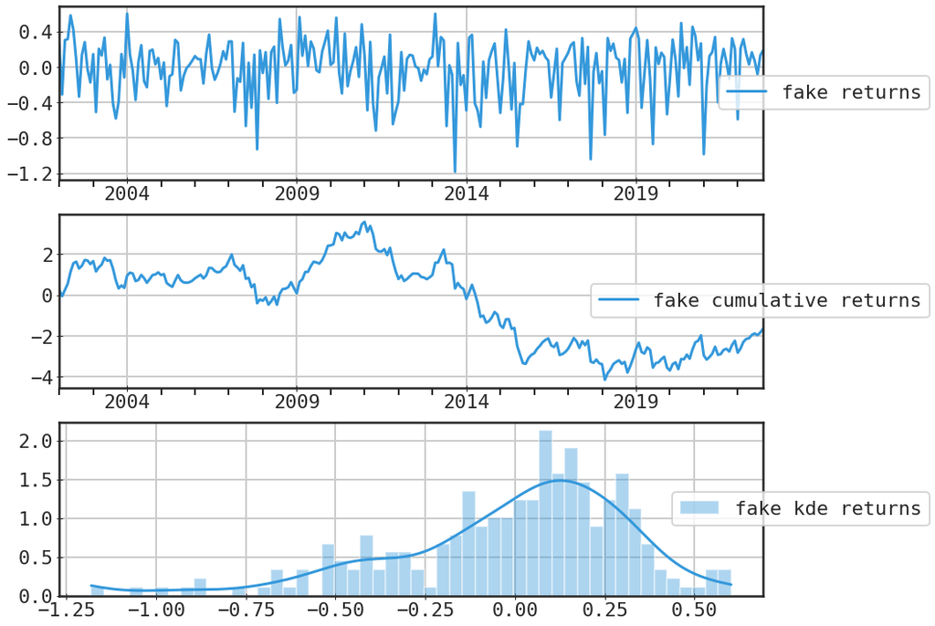

```python
regime_labels = ["stable", "risky"]
true_mus = dict.fromkeys(regime_labels)
true_sigmas = dict.fromkeys(regime_labels)
true_probs = dict.fromkeys(regime_labels)

# ---------------------------------------------------------------------------
# true values
# ---------------------------------------------------------------------------

true_mus["stable"], true_sigmas["stable"] = 0.15, 0.20
true_mus["risky"], true_sigmas["risky"] = -0.25, 0.35

true_probs["stable"] = 0.65
true_probs["risky"] = 1 - true_probs["stable"]

# ---------------------------------------------------------------------------
# mixed up data
# ---------------------------------------------------------------------------

mixed = mix_data(true_mus, true_sigmas, true_probs, n=250)

# ---------------------------------------------------------------------------
# plot mixed up data
# ---------------------------------------------------------------------------

fig, axs = plt.subplots(nrows=3, figsize=(15, 10))

mixed.plot(ax=axs[0], label="fake returns")
mixed.cumsum().plot(ax=axs[1], label="fake cumulative returns")
sns.distplot(mixed, ax=axs[2], kde_kws=dict(cut=0), bins=50, label="fake kde returns")
for ax in axs:
    ax.yaxis.set_major_locator(mpl.ticker.MaxNLocator(5))
    ax.tick_params("both", direction="inout", length=7, width=1, which="major")
    ax.legend(loc="center right", bbox_to_anchor=(1.25, 0.5))
plt.tight_layout()
```

#### Create Expectation and Maximization Functions

```python
def weight_of_regime(regime_ll, total_ll):
    """
    Compute the weights of the regime using the likelihood
    computed using the stats.norm.pdf function

    These weights are used to rescale the data and restimate the parameters
    of the distributions. Those parameters are the mean and std.

    Params
    ------
    regime_ll: array-like
        contains the probability that each datapoint was generated by the
        gaussian distribution with our parameter guesses
    total_ll: array-like
        sum of the likelihoods of both regimes

    Returns
    -------
    array-like
        scaled probability of regime weights for each datapoint
    """
    return regime_ll / total_ll


def estimate_mean(data, weight):
    """
    Re-estimate/update the parameter mean.

    We use the computed regime weight to rescale the data in our update of
    the estimate of the mean

    Params
    ------
    data: array-like
    weight: array-like

    Returns
    -------
    scalar float
        updated estimate of the distribution's mean
    """
    return np.sum(data * weight) / np.sum(weight)


def estimate_std(data, weight, mean):
    """
    Re-estimate/update the parameter std

    We use the updated mean, and the computed regime weights to update
    our estimate of the distribution standard deviation

    Params
    ------
    data: array-like
    weight: array-like
    mean: scalar float

    Returns
    -------
    scalar float
        updated esimate of the distribution's std
    """
    variance = np.sum(weight * (data - mean) ** 2) / np.sum(weight)
    return np.sqrt(variance)









# end
```

#### Initialize our parameter estimates

And plot kde estimate of our guess

```python
def plot_estimates(
    both_regimes,
    stable_mean_est,
    risky_mean_est,
    stable_std_est,
    risky_std_est,
    alpha=1,
):
    """
    Plot parameter estimates of the guassian distributions
        code adapted from: https://github.com/ajcr/em-explanation/blob/master/em-notebook-2.ipynb
    """
    # set figure size and plot the purple dots
    plt.rcParams["figure.figsize"] = (15, 5)
    plt.plot(
        both_regimes, np.zeros_like(both_regimes), ".", color="purple", markersize=10
    )

    # compute the size of the x axis
    lo = np.floor(both_regimes.min()) - 0.25
    hi = np.ceil(both_regimes.max()) + 0.25
    x = np.linspace(lo, hi, 500)

    # plot the bell curves
    plt.plot(
        x, stats.norm(stable_mean_est, stable_std_est).pdf(x), color="b", alpha=alpha
    )
    plt.plot(
        x, stats.norm(risky_mean_est, risky_std_est).pdf(x), color="r", alpha=alpha
    )

    # vertical dotted lines for the mean of each colour - find the height
    # first (i.e. the probability of the mean of the colour group)
    b_height = stats.norm(stable_mean_est, stable_std_est).pdf(stable_mean_est)
    r_height = stats.norm(risky_mean_est, risky_std_est).pdf(risky_mean_est)

    plt.vlines(stable_mean_est, 0, b_height, "b", "--", alpha=alpha)
    plt.vlines(risky_mean_est, 0, r_height, "r", "--", alpha=alpha)







# end
```

#### Initialize our guesses

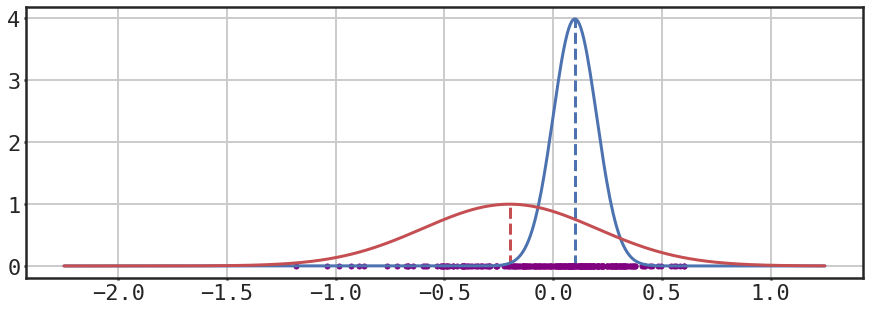

```python
# ---------------------------------------------------------------------------
# initial guesses
# ---------------------------------------------------------------------------
regime_labels = ["stable", "risky"]

mu_est = dict.fromkeys(regime_labels)
sigma_est = dict.fromkeys(regime_labels)

# guesses at starting mean and std
mu_est["stable"], sigma_est["stable"] = 0.10, 0.10
mu_est["risky"], sigma_est["risky"] = -0.2, 0.4

plot_estimates(
    mixed, mu_est["stable"], mu_est["risky"], sigma_est["stable"], sigma_est["risky"]
)
```

#### Code EM demo function

```python
def em_custom(
    both_regimes, mus, sigmas, true_mus, true_sigs, true_probs, tol=0.01, max_iter=100
):
    """
    demo EM algorithm using aforementioned functions
    """

    ms = copy(mus)
    sigs = copy(sigmas)
    stable_wts = 0.5
    risky_wts = 0.5
    alphas = np.linspace(0.2, 1, max_iter)

    lls = list()
    ll_old = 0
    for i in range(max_iter):
        ll_new = 0

        # E-Step
        ll_stable = (
            stats.norm(ms["stable"], sigs["stable"]).pdf(both_regimes) * stable_wts
        )
        ll_risky = stats.norm(ms["risky"], sigs["risky"]).pdf(both_regimes) * risky_wts

        stable_wts = weight_of_regime(ll_stable, ll_stable + ll_risky)
        risky_wts = weight_of_regime(ll_risky, ll_stable + ll_risky)

        ll_new += np.log(ll_stable + ll_risky).sum()
        lls.append(ll_new)

        # M-Step

        # update means
        ms["stable"] = estimate_mean(both_regimes, stable_wts)
        ms["risky"] = estimate_mean(both_regimes, risky_wts)

        # update sigs
        sigs["stable"] = estimate_std(both_regimes, stable_wts, ms["stable"])
        sigs["risky"] = estimate_std(both_regimes, risky_wts, ms["risky"])

        plot_estimates(
            both_regimes,
            ms["stable"],
            ms["risky"],
            sigs["stable"],
            sigs["risky"],
            alpha=alphas[i],
        )

        regime_map = {0: "stable", 1: "risky"}
        total_wts = np.sum(stable_wts) + np.sum(risky_wts)
        iter_data = pd.DataFrame(
            np.vstack(
                [
                    list(ms.values()),
                    list(sigs.values()),
                    [np.sum(stable_wts) / total_wts, np.sum(risky_wts) / total_wts],
                    list(true_mus.values()),
                    list(true_sigs.values()),
                    list(true_probs.values()),
                ]
            ),
            columns=["stable", "risky"],
            index=[
                "means",
                "sigs",
                "weights",
                "true_means",
                "true_sigs",
                "true_weights",
            ],
        ).round(3)

        if np.abs(ll_new - ll_old) < tol:
            print()
            print("-" * 77)
            print(f"convergence achieved at iteration: {i}")
            print(f"ll new: {ll_new:.3f}")
            display(iter_data.T)
            break
        ll_old = ll_new

        if i % 10 == 0:
            print()
            print("-" * 77)
            print(f"iteration: {i}")
            print(f"ll new: {ll_new:.3f}")
            display(iter_data.T)
    return lls








# end
```

#### Run Expectation-Maximization Algorithm

```
-----------------------------------------------------------------------------
iteration: 0
ll new: -68.126
```

|  | means | sigs | weights | true_means | true_sigs | true_weights |
| --- | --- | --- | --- | --- | --- | --- |
| stable | 0.1220 | 0.1200 | 0.4590 | 0.1500 | 0.2000 | 0.6500 |
| risky | -0.1150 | 0.3880 | 0.5410 | -0.2500 | 0.3500 | 0.3500 |

```
-----------------------------------------------------------------------------
iteration: 10
ll new: 66.976
```

|  | means | sigs | weights | true_means | true_sigs | true_weights |
| --- | --- | --- | --- | --- | --- | --- |
| stable | 0.1640 | 0.1100 | 0.5640 | 0.1500 | 0.2000 | 0.6500 |
| risky | -0.2270 | 0.3640 | 0.4360 | -0.2500 | 0.3500 | 0.3500 |

```
-----------------------------------------------------------------------------
iteration: 20
ll new: 68.695
```

|  | means | sigs | weights | true_means | true_sigs | true_weights |
| --- | --- | --- | --- | --- | --- | --- |
| stable | 0.1680 | 0.1080 | 0.5590 | 0.1500 | 0.2000 | 0.6500 |
| risky | -0.2280 | 0.3590 | 0.4410 | -0.2500 | 0.3500 | 0.3500 |

```
-----------------------------------------------------------------------------
iteration: 30
ll new: 69.057
```

|  | means | sigs | weights | true_means | true_sigs | true_weights |
| --- | --- | --- | --- | --- | --- | --- |
| stable | 0.1700 | 0.1090 | 0.5580 | 0.1500 | 0.2000 | 0.6500 |
| risky | -0.2300 | 0.3560 | 0.4420 | -0.2500 | 0.3500 | 0.3500 |

```
-----------------------------------------------------------------------------
iteration: 40
ll new: 69.384
```

|  | means | sigs | weights | true_means | true_sigs | true_weights |
| --- | --- | --- | --- | --- | --- | --- |
| stable | 0.1720 | 0.1100 | 0.5610 | 0.1500 | 0.2000 | 0.6500 |
| risky | -0.2350 | 0.3530 | 0.4390 | -0.2500 | 0.3500 | 0.3500 |

```
-----------------------------------------------------------------------------
iteration: 50
ll new: 69.766
```

|  | means | sigs | weights | true_means | true_sigs | true_weights |
| --- | --- | --- | --- | --- | --- | --- |
| stable | 0.1740 | 0.1110 | 0.5650 | 0.1500 | 0.2000 | 0.6500 |
| risky | -0.2400 | 0.3490 | 0.4350 | -0.2500 | 0.3500 | 0.3500 |

```
-----------------------------------------------------------------------------
iteration: 60
ll new: 70.081
```

|  | means | sigs | weights | true_means | true_sigs | true_weights |
| --- | --- | --- | --- | --- | --- | --- |
| stable | 0.1750 | 0.1120 | 0.5670 | 0.1500 | 0.2000 | 0.6500 |
| risky | -0.2440 | 0.3460 | 0.4330 | -0.2500 | 0.3500 | 0.3500 |

```
-----------------------------------------------------------------------------
iteration: 70
ll new: 70.097
```

|  | means | sigs | weights | true_means | true_sigs | true_weights |
| --- | --- | --- | --- | --- | --- | --- |
| stable | 0.1750 | 0.1120 | 0.5660 | 0.1500 | 0.2000 | 0.6500 |
| risky | -0.2430 | 0.3460 | 0.4340 | -0.2500 | 0.3500 | 0.3500 |

```
-----------------------------------------------------------------------------
iteration: 80
ll new: 70.116
```

|  | means | sigs | weights | true_means | true_sigs | true_weights |
| --- | --- | --- | --- | --- | --- | --- |
| stable | 0.1750 | 0.1120 | 0.5650 | 0.1500 | 0.2000 | 0.6500 |
| risky | -0.2430 | 0.3460 | 0.4350 | -0.2500 | 0.3500 | 0.3500 |

```
-----------------------------------------------------------------------------
iteration: 90
ll new: 70.153
```

|  | means | sigs | weights | true_means | true_sigs | true_weights |
| --- | --- | --- | --- | --- | --- | --- |
| stable | 0.1760 | 0.1110 | 0.5630 | 0.1500 | 0.2000 | 0.6500 |
| risky | -0.2420 | 0.3450 | 0.4370 | -0.2500 | 0.3500 | 0.3500 |

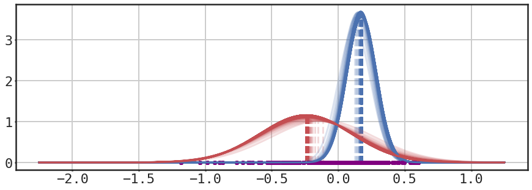

```python
ll = em_custom(mixed, mu_est, sigma_est, true_mus, true_sigmas, true_probs, tol=1e-9)
```

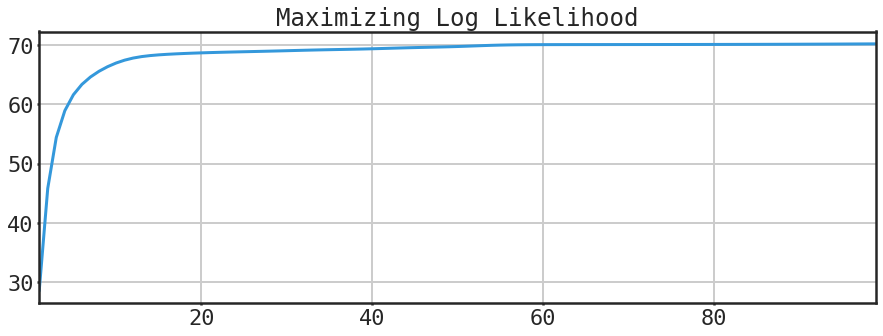

```python
pd.Series(ll)[1:].dropna().plot()
plt.title("Maximizing Log Likelihood")
```

Not bad right? This algorithm is pretty flexible although you can adjust the true parameters and/or the guesses and you will find some of the limitations. However how those are addressed are beyond the scope of this chapter.

My goal was to provide a simple working example of the algorithm, in order for us to gain a deeper understanding of what is happening inside the black box of the algorithm.

Now we can move forward.

## Fitting Mixture Models Using Real Data

#### Import return data

```python
infp = Path(data_dir / "tiingo_etf_returns_ending_2017-12-31.parq")
R = pd.read_parquet(infp).assign(
    year=lambda df: df.index.year
)  # add year column for later conv.
cprint(R)
```

```
-------------------------------------------------------------------------------
dataframe information
-------------------------------------------------------------------------------
               SPY     QQQ     TLT    GLD     EFA     EEM  year
date
2017-12-22 -0.0003 -0.0011  0.0014 0.0052  0.0026  0.0084  2017
2017-12-26 -0.0012 -0.0054  0.0030 0.0068 -0.0003 -0.0009  2017
2017-12-27  0.0005  0.0001  0.0129 0.0038  0.0019  0.0026  2017
2017-12-28  0.0021  0.0012 -0.0009 0.0051  0.0006  0.0068  2017
2017-12-29 -0.0038 -0.0062  0.0016 0.0065  0.0007  0.0047  2017
--------------------------------------------------
<class 'pandas.core.frame.DataFrame'>
DatetimeIndex: 3301 entries, 2004-11-19 to 2017-12-29
Data columns (total 7 columns):
SPY     3301 non-null float64
QQQ     3301 non-null float64
TLT     3301 non-null float64
GLD     3301 non-null float64
EFA     3301 non-null float64
EEM     3301 non-null float64
year    3301 non-null int64
dtypes: float64(6), int64(1)
memory usage: 206.3 KB
None
-------------------------------------------------------------------------------
```

```python
sym = "SPY"  # example symbol
df = R.loc["2005":].copy()  # use 2005 cutoff b/c it's first full year of data
df.info()
```

```
<class 'pandas.core.frame.DataFrame'>
DatetimeIndex: 3272 entries, 2005-01-03 to 2017-12-29
Data columns (total 7 columns):
SPY     3272 non-null float64
QQQ     3272 non-null float64
TLT     3272 non-null float64
GLD     3272 non-null float64
EFA     3272 non-null float64
EEM     3272 non-null float64
year    3272 non-null int64
dtypes: float64(6), int64(1)
memory usage: 204.5 KB
```

### Demo scikit-learn function

Continuing with our example, using SPY returns, let's use sklearn to fit a GMM model. First we will fit one using a single component. This is equivalent to fitting a single normal distribution to the set of returns.

```python
def make_gmm(n_components, max_iter=150, random_state=RANDOM_STATE):
    """fn: create gmm object"""
    model_kwds = dict(
        n_components=n_components,
        max_iter=max_iter,
        n_init=100,
        random_state=RANDOM_STATE,
    )

    gmm = mix.GaussianMixture(**model_kwds)
    return gmm


def print_gmm_results(gmm, X):
    print("-" * 25)
    print(f"means: {gmm.means_.ravel()}")
    print("-" * 25)
    print(f"covars: {gmm.covariances_.ravel()}")
    print("-" * 25)
    print(f"sqrt covar: {np.sqrt(gmm.covariances_.ravel())}")
    print("-" * 25)
    print(f"aic: {gmm.aic(X):.5f}")
    print(f"bic: {gmm.bic(X):.5f}")
    print("-" * 25)
```

```python
s = df[sym].copy()
max_iter = 150
_X = s.values.reshape(-1, 1)

gmm1 = make_gmm(1, max_iter)
gmm1.fit(_X)

preds = gmm1.predict(_X)

print_gmm_results(gmm1, _X)
print(f"data derived mean: {s.mean():.7f}")
print(f"data derived std: {s.std():.7f}")
```

```
-------------------------
means: [0.00032246]
-------------------------
covars: [0.00014067]
-------------------------
sqrt covar: [0.01186028]
-------------------------
aic: -19753.49068
bic: -19741.30437
-------------------------
data derived mean: 0.0003225
data derived std: 0.0118199
```

### How to Choose the Right Number of Components?

#### Comparing AIC and BIC of Different numbers of Component Mixtures

Note that the mean and standard deviation is the same as computed in the previous plot. Also note the `aic` and `bic` metrics. These reference the [`Akaike Information Criterion`](https://en.wikipedia.org/wiki/Akaike_information_criterion) and the [`Bayesian Information Criterion`](https://en.wikipedia.org/wiki/Bayesian_information_criterion). Without delving too heavily into the theoretical pros and cons of each, we can just say they are both methods which allow us to compare the relative suitability of different models. Generally speaking, when choosing among a set of models we want to choose the `aic` or `bic` with the smallest information criterion value.

> AIC rewards goodness of fit (as assessed by the likelihood function), but it also includes a penalty that is an increasing function of the number of estimated parameters. The penalty discourages overfitting, because increasing the number of parameters in the model almost always improves the goodness of the fit. - [wikipedia](https://en.wikipedia.org/wiki/Akaike_information_criterion)

The importance of the penalty component in each of the ICs cannot be overstated. As always, in the limit, you could technically fit a distribution, or add a parameter for *every* datapoint, thereby grossly overfitting the model.

Both metrics implement a penalty, however the `bic` penalizes additional parameters more heavily than the `aic` and will always result in a selecting fewer parameters than the `aic` would. Let's walkthrough a quick demo of this.

```python
gmm2 = make_gmm(2, max_iter)
gmm2.fit(_X, s.index.values)

print_gmm_results(gmm2, _X)
```

```
-------------------------
means: [-0.00268973  0.00091173]
-------------------------
covars: [6.12461112e-04 4.62464804e-05]
-------------------------
sqrt covar: [0.02474795 0.00680048]
-------------------------
aic: -20958.46560
bic: -20927.99982
-------------------------
```

Above we fit a GMM model with `2` components. Notice that both the `aic` and `bic` are smaller than their single component counterparts. This implies that the model with `2` components is "better" than the one with a single component. What about more components? Let's try `15`.

```python
gmm15 = make_gmm(15, max_iter)
gmm15.fit(_X)

print_gmm_results(gmm15, _X)
```

```
-------------------------
means: [-0.00317625  0.03013596 -0.01505498  0.00425292 -0.04339227  0.12224095
  0.01393339 -0.02491553 -0.00868684 -0.0761712   0.0202671   0.04015584
  0.00041272  0.00867713  0.06070379]
-------------------------
covars: [5.93193365e-06 1.13969254e-05 1.06560664e-05 5.53172816e-06
 4.75481776e-05 7.22938574e-05 7.86298123e-06 2.01976422e-05
 7.65005686e-06 2.24881625e-04 1.01695723e-05 1.22911787e-05
 4.90814704e-06 6.23299305e-06 4.71088727e-05]
-------------------------
sqrt covar: [0.00243556 0.00337593 0.00326436 0.00235196 0.00689552 0.00850258
 0.0028041  0.00449418 0.00276587 0.01499605 0.00318898 0.00350588
 0.00221543 0.0024966  0.00686359]
-------------------------
aic: -21075.43582
bic: -20807.33692
-------------------------
```

Now we see an example where the `aic` has improved by getting smaller but the `bic` is actually larger than the `2` component model. Here we see the result of the `bic` penalizing additional parameters more heavily.

#### Choosing The Optimal Number of Components using AIC/BIC

Below we can see a comparison between the two metrics as we increase the number of components. We can also see that they choose different numbers of optimal components.

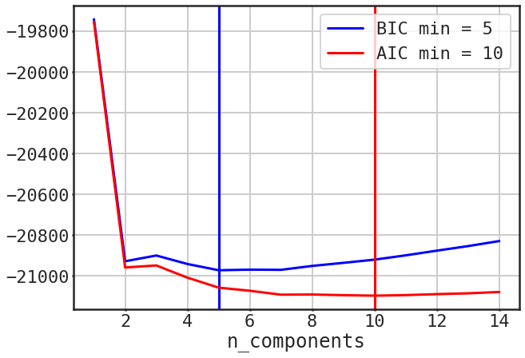

```python
n_components = np.arange(1, 15)
aics = []
bics = []

for n in n_components:
    tmp_gmm = make_gmm(n, max_iter).fit(_X)
    aics.append((n, tmp_gmm.aic(_X)))
    bics.append((n, tmp_gmm.bic(_X)))

bics = make_ic_series(bics, "bic")
aics = make_ic_series(aics, "aic")

plt.figure(figsize=(10, 7))
plt.plot(n_components, bics.values, color="blue", label=f"BIC min = {np.argmin(bics)}")
plt.axvline(np.argmin(bics), color="blue")

plt.plot(n_components, aics.values, color="red", label=f"AIC min = {np.argmin(aics)}")
plt.axvline(np.argmin(aics), color="red")

plt.legend(loc="best")
plt.xlabel("n_components")
```

## Visualizing Regimes

Note what we make use of the `TimeSeriesSplit` tool from `sklearn` to implement our walkforward testing.

```python
def plot_results(_X, Y, means, covariances):
    plt.figure()
    X = _X.values.reshape(-1, 1)
    for i, (mean, covar, color) in enumerate(zip(means, covariances, colors)):
        plt.scatter(
            _X.index[Y == i],
            X[Y == i],
            100,
            color=color,
            edgecolors="k",
            linewidths=1.5,
            label=f"{i}th hidden state",
        )
        plt.xlim(_X.index.min(), _X.index.max())
        plt.xticks(rotation=45)
        plt.legend()

    min_idx_str = _X.index.min().strftime("%Y/%m/%d")
    max_idx_str = _X.index.max().strftime("%Y/%m/%d")
    title_text = f"Period ${min_idx_str}$ through ${max_idx_str}$"
    plt.title(title_text, fontsize=17, fontweight="medium")

    # outfp=Path(pdir/'visuals'/'02_Gaussian_Mixtures'/f'hidden_states_example_{min_idx_str}_{max_idx_str}.png')
    # outfp=outfp.as_posix()
    # plt.savefig(outfp,**savefig_kwds)
```

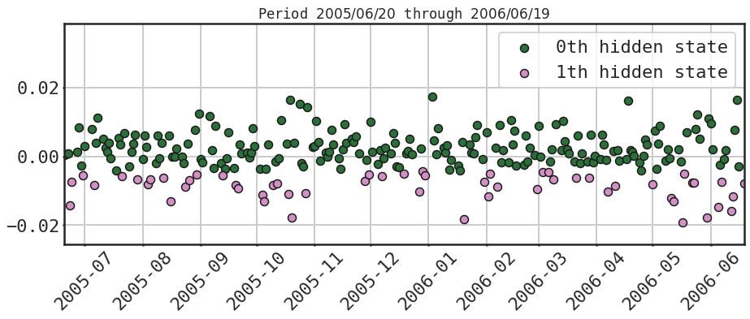

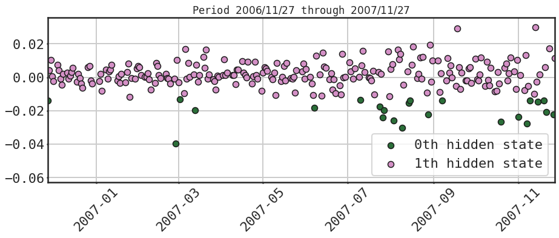

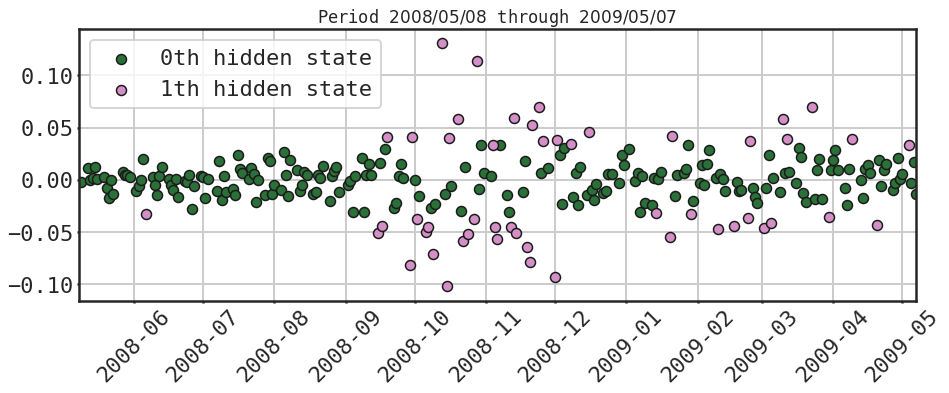

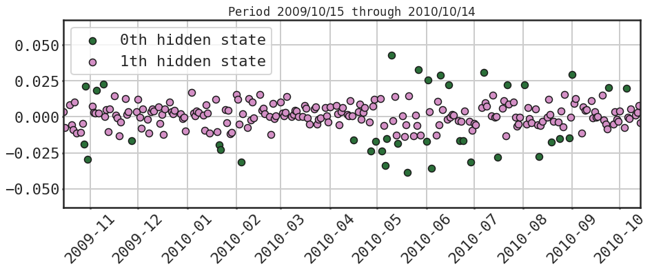

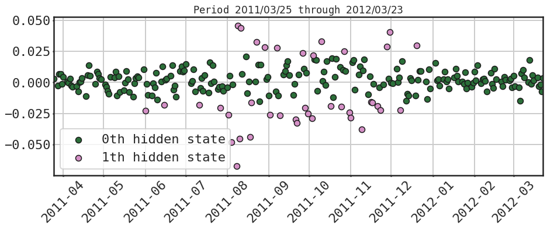

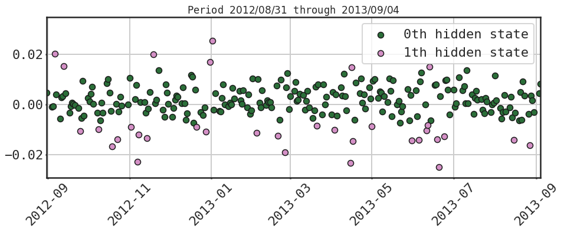

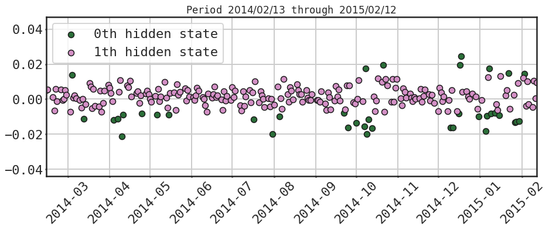

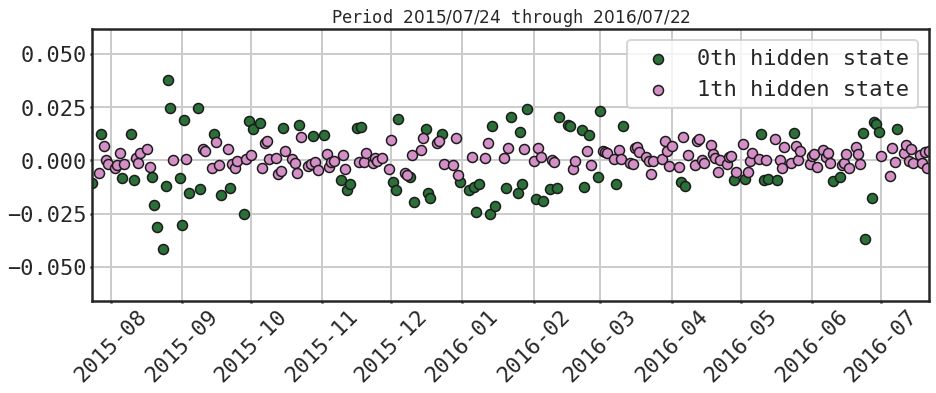

```python
np.random.seed(0)

lookback = 252
n_components = 2
max_iter = 1000
n_split = n_components * 4

# stash data in lists
preds = []
pred_means = []
pred_covs = []

### begin plot code ###
fig = plt.figure(figsize=(12, 7))
colors = sns.color_palette("cubehelix", n_components)

tscv = TimeSeriesSplit(n_splits=n_split, max_train_size=lookback)

for i, (train, test) in enumerate(tscv.split(s)):
    tmp_train = s.iloc[train]  # temporary train data
    tmp_test = s.iloc[test]  # temporary test data

    _X = tmp_train.values.reshape(-1, 1)  # format pd.Series for sklearn
    y = tmp_train.index.values
    gmm = make_gmm(n_components, max_iter)  # make model
    gmm.fit(_X, y)  # fit model

    # predict hidden states
    hidden_states = gmm.predict(_X)

    # store output in lists
    preds.append(hidden_states)
    pred_means.append(gmm.means_)
    pred_covs.append(gmm.covariances_)

    plot_results(
        tmp_train,
        gmm.predict(tmp_train.values.reshape(-1, 1)),
        gmm.means_,
        gmm.covariances_,
    )








# end
```

We can see how varied the components are across different time periods. Some components are more active while others are rarely active. Additionally notice how some components are clustered over shorter sub periods while others are more evenly distributed.

#### Sampling from the GMM

What's cool about the GMM model is we can also sample directly from the posterior to generate new samples. Using the last training values from the visual example above we can see how to sample below.

The `X_s` variable is a numpy array containing the value estimates while the `y_s` contain the component labels.

```python
X_s, y_s = gmm.sample(n_samples=len(tmp_train))
```

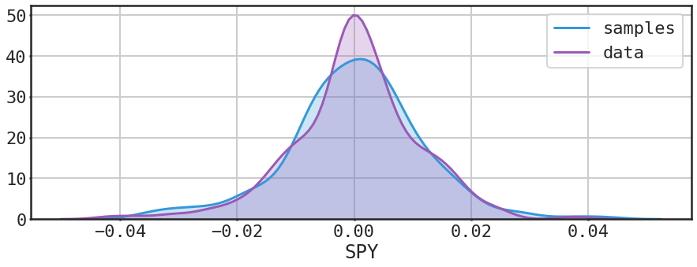

```python
plt.figure()
sns.distplot(
    pd.Series(X_s.ravel()),
    ax=plt.gca(),
    label="samples",
    hist=False,
    kde_kws=dict(shade=True),
)
sns.distplot(
    pd.Series(tmp_train),
    ax=plt.gca(),
    label="data",
    hist=False,
    kde_kws=dict(shade=True),
)
plt.legend()
```

Next we visualize these relationships further. For each time period, we show a boxplot color coded to represent the different components. of the aggregate returns over the period. Finally we print out the statistical description of the dataframe using `pandas.describe()`.

#### Plot convenience functions

```python
def plot_states_boxplot(states, state_col, y_col):
    g = (
        pn.ggplot(states, pn.aes(x=state_col, y=y_col, color=f"factor({state_col})"))
        + pn.geom_boxplot()
        + pn.geom_jitter(alpha=0.5)
        + pn.geom_hline(yintercept=0.0, size=1, linetype=":", color="red")
        + pn.scale_y_continuous(
            breaks=mzb.mpl_breaks(),
            labels=mzf.percent_format(),
            limits=(states[y_col].min(), states[y_col].max()),
        )
        + pn.theme_linedraw()
        + pn.theme(
            panel_background=pn.element_rect(fill="black"),
            axis_text_x=pn.element_text(rotation=30),
        )
        + pn.ylab("log returns")
        + pn.ggtitle("Log Returns by Hidden State")
    )
    return g
```

### Visualizing the train test split regimes

With the plotting functions defined we can loop through the `TimeseriesSplit` object to generate the plots and descriptive tables for each lookback/training period.

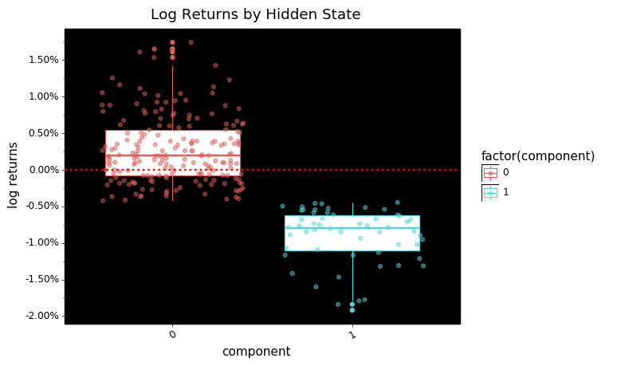

| component | 0 | 1 |
| --- | --- | --- |
| count | 196.0000 | 56.0000 |
| mean | 0.0028 | -0.0091 |
| std | 0.0046 | 0.0038 |
| min | -0.0042 | -0.0192 |
| 25% | -0.0007 | -0.0110 |
| 50% | 0.0019 | -0.0080 |
| 75% | 0.0055 | -0.0062 |
| max | 0.0174 | -0.0045 |

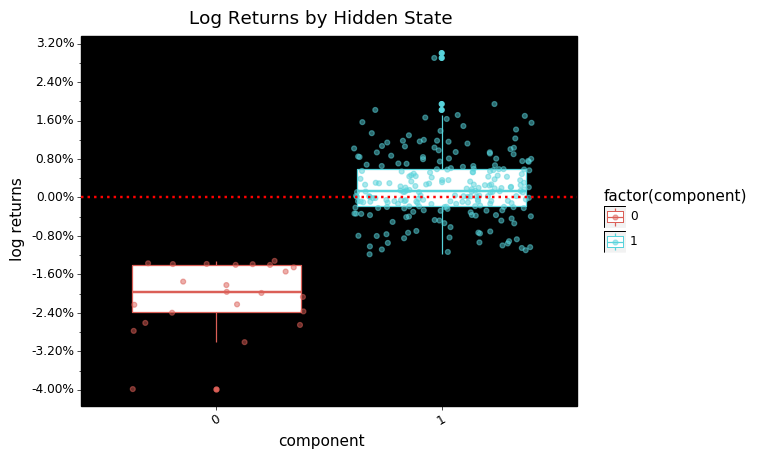

| component | 0 | 1 |
| --- | --- | --- |
| count | 23.0000 | 229.0000 |
| mean | -0.0202 | 0.0022 |
| std | 0.0068 | 0.0068 |
| min | -0.0398 | -0.0118 |
| 25% | -0.0238 | -0.0018 |
| 50% | -0.0196 | 0.0014 |
| 75% | -0.0140 | 0.0059 |
| max | -0.0132 | 0.0300 |

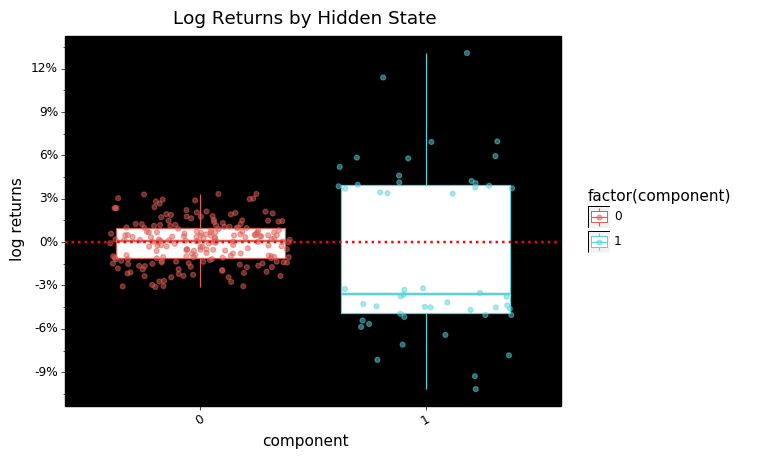

| component | 0 | 1 |
| --- | --- | --- |
| count | 202.0000 | 50.0000 |
| mean | -0.0000 | -0.0079 |
| std | 0.0146 | 0.0564 |
| min | -0.0310 | -0.1016 |
| 25% | -0.0108 | -0.0489 |
| 50% | 0.0008 | -0.0358 |
| 75% | 0.0096 | 0.0395 |
| max | 0.0333 | 0.1307 |

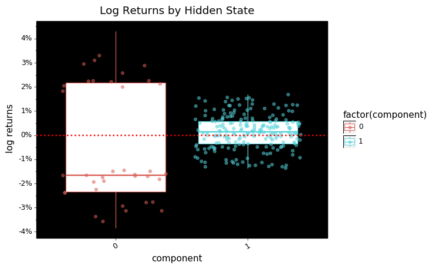

| component | 0 | 1 |
| --- | --- | --- |
| count | 38.0000 | 214.0000 |
| mean | -0.0049 | 0.0013 |
| std | 0.0247 | 0.0070 |
| min | -0.0385 | -0.0137 |
| 25% | -0.0235 | -0.0035 |
| 50% | -0.0165 | 0.0013 |
| 75% | 0.0219 | 0.0057 |
| max | 0.0431 | 0.0168 |

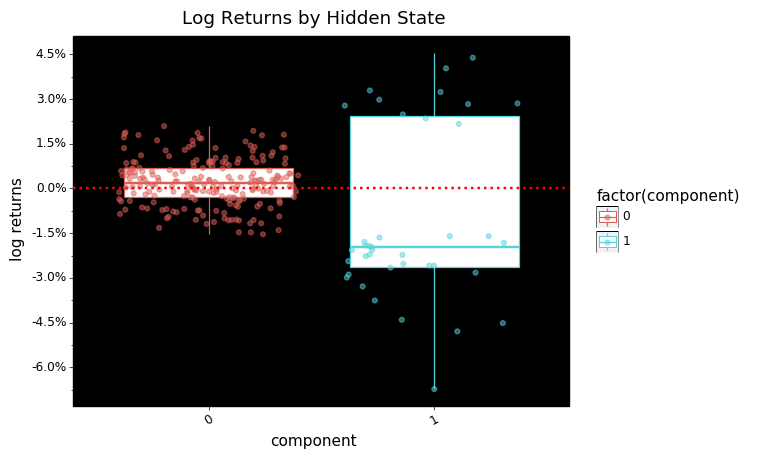

| component | 0 | 1 |
| --- | --- | --- |
| count | 213.0000 | 39.0000 |
| mean | 0.0021 | -0.0093 |
| std | 0.0079 | 0.0296 |
| min | -0.0154 | -0.0673 |
| 25% | -0.0030 | -0.0262 |
| 50% | 0.0019 | -0.0196 |
| 75% | 0.0070 | 0.0242 |
| max | 0.0209 | 0.0455 |

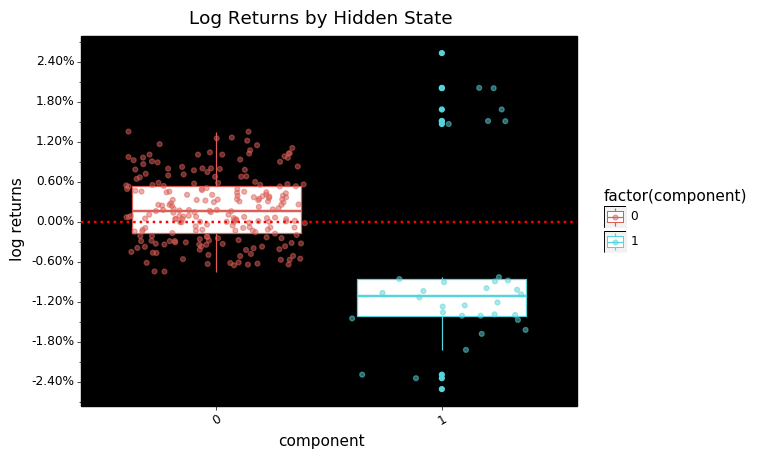

| component | 0 | 1 |
| --- | --- | --- |
| count | 218.0000 | 34.0000 |
| mean | 0.0020 | -0.0071 |
| std | 0.0049 | 0.0138 |
| min | -0.0075 | -0.0251 |
| 25% | -0.0017 | -0.0141 |
| 50% | 0.0016 | -0.0111 |
| 75% | 0.0053 | -0.0086 |
| max | 0.0135 | 0.0253 |

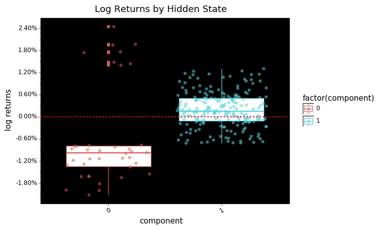

| component | 0 | 1 |
| --- | --- | --- |
| count | 38.0000 | 214.0000 |
| mean | -0.0061 | 0.0018 |
| std | 0.0131 | 0.0047 |
| min | -0.0213 | -0.0072 |
| 25% | -0.0136 | -0.0011 |
| 50% | -0.0099 | 0.0014 |
| 75% | -0.0079 | 0.0050 |
| max | 0.0244 | 0.0130 |

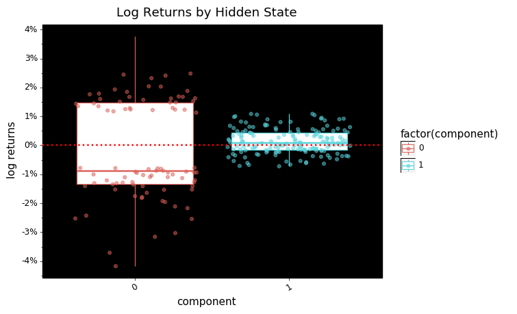

| component | 0 | 1 |
| --- | --- | --- |
| count | 89.0000 | 163.0000 |
| mean | -0.0018 | 0.0013 |
| std | 0.0171 | 0.0043 |
| min | -0.0417 | -0.0072 |
| 25% | -0.0135 | -0.0016 |
| 50% | -0.0088 | 0.0007 |
| 75% | 0.0148 | 0.0044 |
| max | 0.0377 | 0.0109 |

```python
### RUN` ###
for i, (train, test) in enumerate(tscv.split(s)):
    tmp_train = s.iloc[train].values.reshape(-1, 1)  # temporary train data
    tmp_test = s.iloc[test].values.reshape(-1, 1)  # temporary test data

    gmm = make_gmm(n_components, max_iter)
    gmm.fit(tmp_train, s.iloc[train].index.values)

    hidden_states_prob = gmm.predict_proba(tmp_train)
    hidden_states = gmm.predict(tmp_train)

    state_df = (
        s.iloc[train]
        .to_frame()
        .assign(component=pd.Categorical(hidden_states))
        .assign(mkt_cret=lambda df: df[sym].cumsum())
        .reset_index()
    )

    scol = "component"
    g2 = plot_states_boxplot(state_df, scol, sym)
    print()
    print("*" * 77)
    print(g2)
    display(state_df.groupby(scol)[sym].describe().T)
```

## Conclusions

In this chapter we covered the intuition behind Gaussian Mixture Models (GMM) and how they work. We peeled back the curtain and went through a demonstration of the underlying Expectation-Maximization algorithm that underpins GMMs and many other unsupervised algorithms. From there we used `sklearn` to fit a GMM, and how to make a good choice about the optimal number of components to fit. Finally we demonstrated some of the flexibility and variability of GMMs to fit time-varying distributions.

In the next chapter we will examine a question posed to me by one of the quantinsti students. Are the mixture model components more stationary than the dataset as a whole?

## Resources and Citations

1. https://github.com/ajcr/em-explanation/blob/master/em-notebook-2.ipynb
2. https://jakevdp.github.io/PythonDataScienceHandbook/05.12-gaussian-mixtures.html